# Model selection for predictive model development

# 1 Introduction

Model selection is inherent to the statistician work which aims to explain the observed data. According to a model, we want to infere the impact of different factors (estimate parameters and their variances) on the variable of interest. This impact should be evaluated differently according to the aim of the model.

From a predictive point of view, we want to reproduce the data generating processus, i.e. we define a model which aims to best predict the **response variable** of future observations according **predictor variables**. We don’t consider that it is not possible to develop a model which is similar the “nature”/“reallity”, but we try to approximate it. So, we try to define a model which well reproduce the data generating process. With this assumption, we know that the model is wrong, so the paramaters cannot be interpreted as the true relation between the response and predictors. So, without care of interpretability, we consider only the **predictors** which contribute significantly to predictive performance and remove the others, even if they are known risk factors (e.g. if the age does not contribute to predictive performance, we remove it from the model, even if it is known as risk factor). Moreover, without care of interpretability, we can use very flexible models (e.g. splines,…) which are too complex for human interpretation. That’s the domain of “data science” where the deep learning methods, random forest and others very complex methods are daily used, at the risk of overfitting, i.e. the model becomes too sensible to the sample specificities and cannot be generalized to an other (future) sample, decreasing the predictive performance. The “small” sample size and the need of interpretability in health studies prevent the use of these methods.

In health study, we can find several **predictive risk scores** developped with intermediate strategy. The model is developped according to a predictive criterion, but known risk factors are forced for interpretability. Beyond interpretability, some factors are forced for practical considerations: if a risk model with age only has an AUC (see next notebook on predictive models) of 0.75 and a model using only the expression of 3 genes has an AUC of 0.77, the model with age only will be considered because the difference of prediction accuracy lead to non-significant benefit (in term of clinical point of view, not statistical point of view), regarding to the consequence of the price of systematic sequencing.

In this notebook, we will describe the strategy of the development of explanatory model (see expModSelec_notebook.Rmd notebook).

No interpretability because we know that the model is wrong. As only approx, we just want that it can reproduce the best the DGP. So, no assumption testing and no-p-values, just predictive performance criteria. –> predictor removed is not because no impact on the risk, but maybe bring too much redundant info with another predictor -> no biological interpretation possible!!!!!!!!!!!! Ex: if if people in city smoke more, it is correlated to the air polution. The parcimony require in modeling favor simple model, on of them will be remove to remove redundancy of information (but both are causal!!!).

# 2 Predictive modeling

Predictive modeling strategy is different from explanatory one:

- Obtain the best fit (according to the maximum likelihood) to the data is not a good thing
- Model selection based on prediction perf crit
- Considering a complex DGP, there is an opposition between prediction performance and interpretability
- Assumption checking caracteristic of explanatory, not in predictive, so no test nor p-values…

## 2.1 Different Types of Risk Prediction Models

Risk prediction models can focus on a wide variety of clinical outcomes.We discern diagnostic, prognostic, and treatment effect prediction models.

Model selection is inherent to the statistician work which aims to explain the observed data. According to a model, we want to infer the impact of different factors (estimate parameters and their variances) on the variable of interest. This impact should be evaluated differently according to the aim of the model.

From a predictive point of view, we want to reproduce the data generating process, i.e. we define a model which aims to best predict the **response variable** of future observations according **predictor variables**. We consider that it is not possible to develop a model which is similar the “nature”/“reality”, but we try to approximate it. So, we try to define a model which well reproduce the data generating process. With this assumption, we know that the model is wrong, so the parameters cannot be interpreted as the true relation between the response and predictors. So, without care of interpretability, we consider only the **predictors** which contribute significantly to predictive performance and remove the others, even if they are known risk factors (e.g. if the age does not contribute to predictive performance, we remove it from the model, even if it is known as risk factor). Moreover, without care of interpretability, we can use very flexible models (e.g. splines,…) which are too complex for human interpretation. That’s the domain of “data science” where the deep learning methods, random forest and others very complex methods are daily used, at the risk of overfitting, i.e. the model becomes too sensible to the sample and cannot be generalized to an other (future) sample, decreasing the predictive performance. The “small” sample size and the need of interpretability in health studies prevent the use of these methods.

In health study, we can find several **predictive risk scores** developed with intermediate strategy. The model is developed according to a predictive criterion, but known risk factors are forced for interpretability. Beyond interpretability, some factors are forced for practical considerations: if a risk model with age only has an AUC (see next notebook on predictive models) of 0.75 and a model using only the expression of 3 genes has an AUC of 0.77, the model with age only will be considered because the difference of prediction accuracy lead to non-significant benefit (in term of clinical point of view, not statistical point of view), regarding to the consequence of the price of systematic sequencing.

In this notebook, we will describe the strategy of the development of explanatory model (see expModSelec_notebook.Rmd notebook).

# 2 Predictive modeling

Predictive modeling strategy is different from the explanatory strategy:

- Obtain the best fit (according to the maximum likelihood) to the data is not a good thing (risk of overfitting, low generalizability to other data)
- The parcimony in predictive modeling required to limit overfitting favors simple models. Variables providing redundant information compared to other better predictor (e.g. confounding factors) will be removed during model selection, limiting interpretability
- If we consider that all models are wrong, the assumptions of the relationship between variables are ill-posed. Therefore, the model development does not rely on assumption testing (so, no test and p-value, no interpretation of coefficient in term of variable relationship), but on predictive criteria

## 2.1 Different Types of Risk Prediction Models

Risk prediction models can focus on a wide variety of clinical outcomes. We discern diagnostic, prognostic, and treatment effect prediction models:

- Diagnostic prediction models estimate the probability that a patient has an event or disease at the time of examination, ex: for example, whether a tumor is benign or malignant in order to decide how to manage the patient.
- Prognostic models estimate the risk that a clinically relevant endpoint will happen in the future, ex: prognostic risk prediction models may aim to predict the development of the disease in order to assist clinicians with therapeutic decision-making.
- Treatment effect models estimate the probability of a clinically relevant outcome conditional on having received particular treatments, ex: treatment allocation in precision medicine

In this document, we will focus on the development of a prognostic model using the *flchain* dataset of the *survAUC* package.

## 2.2 Model complexity: Underfitting & overfitting

The main assumption is that the observations are generating by a process with noise:

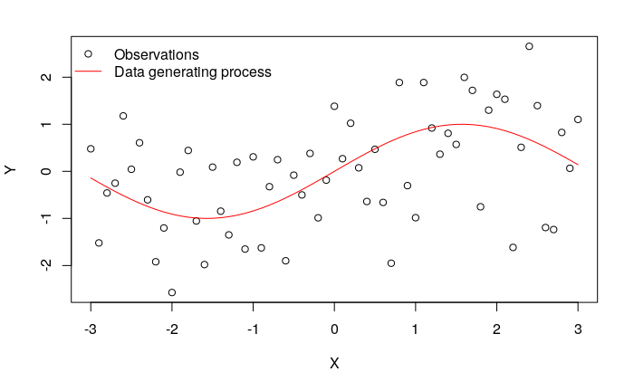

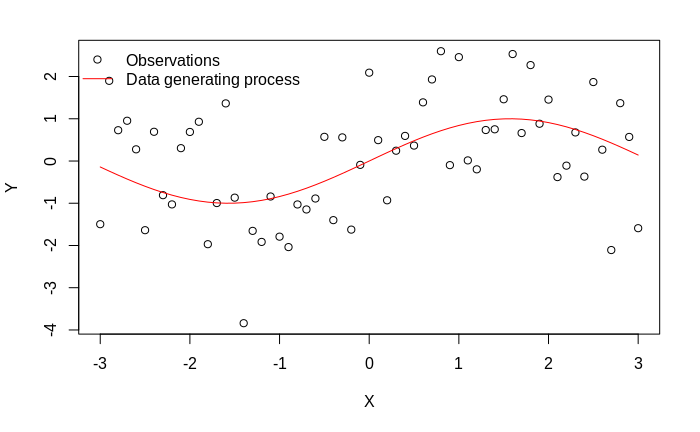

When we define a model, we can favor simple model for interpretability (ex: linear regression), or complex model (ex: spline) to approximate the complex data generating process.

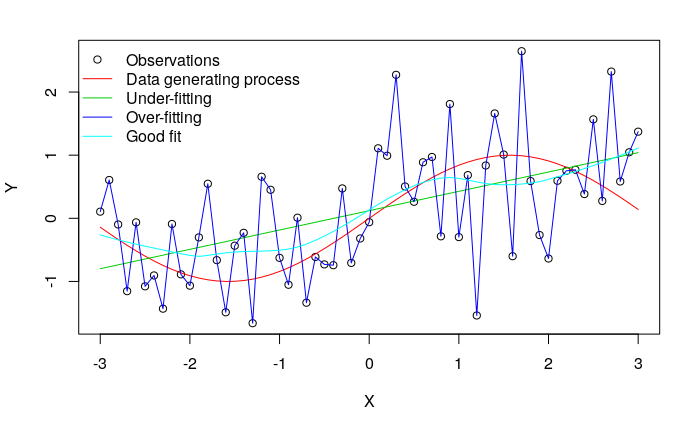

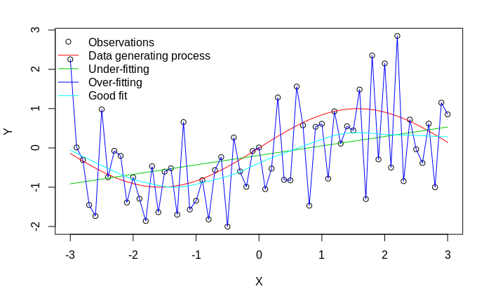

From new observations, the data will have the same trend, but the point will not be to the same location due to the random noise. The goal of predictive model is to develop a model which is enough flexible to approximate the process which generate the data, but not too flexible to be robust to the random noise.

### 2.2.1 Underfitting

Underfitted model will not vary a lot with the random noise. It will be robust to the noise:

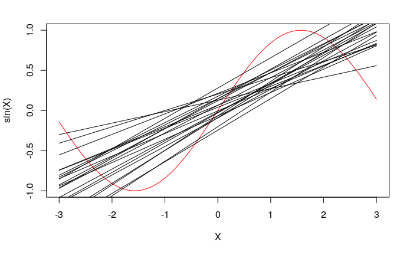

But the data generative trend is not captured and the bias (relative to the data) is large. It will have poor prediction performance to (current and new) data.

Underfitted model will not vary much with the random noise. It will be robust to the noise:

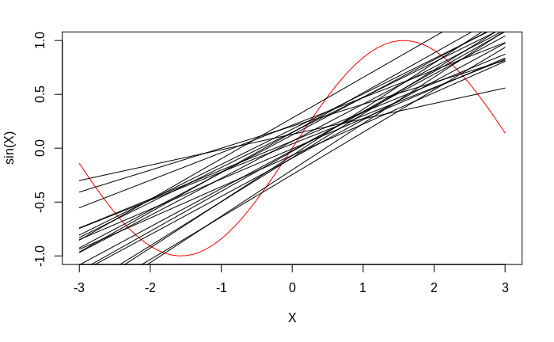

But the data generative process trend is not captured and the bias (relative to the data) is large. It will have poor prediction performance to (current and new) data.

### 2.2.2 Overfitting

Overfitted model will vary a lot with the random noise:

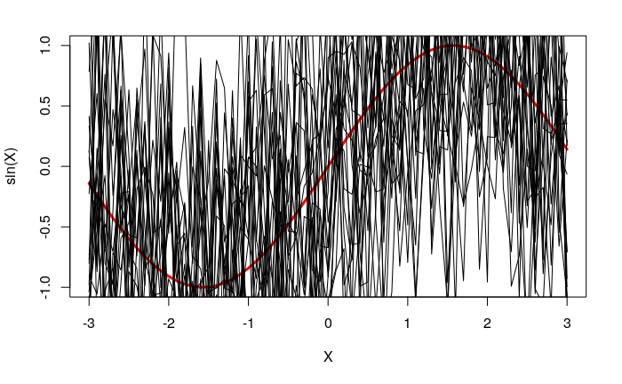

The bias to the data is really low, but the model change for each new data. One model fitted on one data will provide very poor prediction for a new data

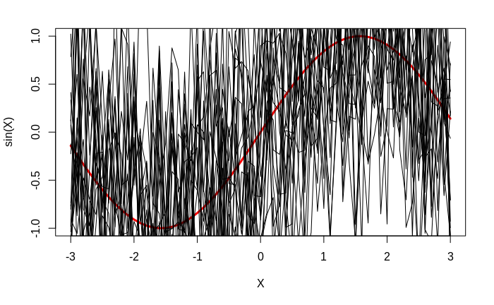

The bias to the data is really low, but the model change for each new data. It is clear that one model fitted on one data will provide very poor prediction for a new data.

### 2.2.3 Bias-variance trade-off

Due to the random noise, the data generating process as a bias (relatively to observation) but is invariant. The aim of predictive modeling is to have a model with a good bias-variance trade-off:

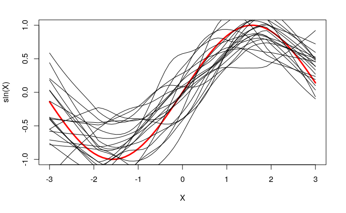

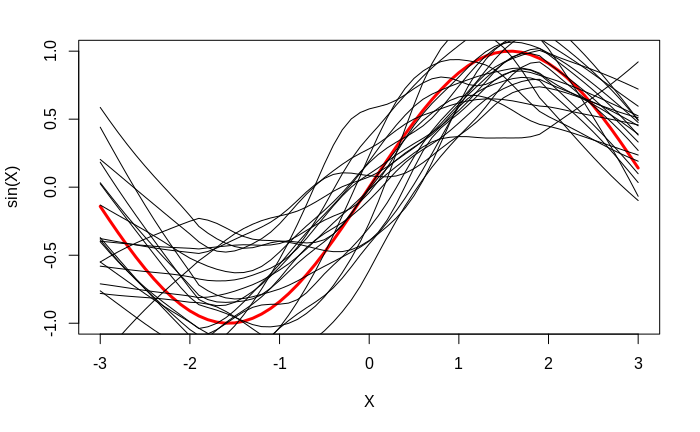

This model is clearly more robust to the random noise than the overfitted model, but less than the underfitted model. On the other hand, its bias is lower than the underfitted model but larger than the overfitted model. This compromise provides better predictive performance.

# 3 Model development strategy

The model complexity should be regulated according to a predictive criterion to find this best compromise. The common way is to compare the difference between the prediction of the model and the observed data.

As this difference is null for overfitted model, the databases for the **training** of the model and its **test** (evaluation of the difference between the predictions and observations) should be different. The best option is to develop the model on a dataset (a part used as **training set** and another for **test set**) and have an external dataset (= **validation** set, similar population but not coming from the same study) to quantify the generalizability of the model to new data set.

The main idea is to train the models on different data than the one on which they are compared

## 3.1 Internal validation

The first strategy is to compare the candidate models on our dataset. The data is split in a **training set** to train the models and compare them on a **test set**.

### 3.1.1 Hold-out

The hold-out strategy consists of randomly hold out a part of the data set (usually ~20%), develop the models on the remaining part of the original dataset, and validate them on the held-out part dataset (**test set**).

Let’s try with the *lung* data set:

```r
rdmData<-sample(lung,nrow(lung))
```

[output not shown]

## 3.1 Remove a priori useless predictors

Such as explanatory strategy, removing a prior known variable which are not predictor is useful do decrease the noise in the starting model.

## 3.2 Internal validation

The first strategy is to compare the candidate models on our dataset. The data is split in a **training set** to train the models and compare them on a **test set**.

### 3.2.1 Hold-out

The hold-out strategy consists of randomly hold out a part of the data set (usually ~20%), develop the models on the remaining part of the original dataset, and validate them on the held-out part dataset (**test set**).

Let’s try with the *flchain* data set:

```r
set.seed(1) #As this procedure depends on random number generation, define the seed at the begining of the code to ensure that you can reproduce the results
idx<-sample(1:nrow(flchain),nrow(flchain)) #mix the data line indexes
nbHoldOut<-round(0.2*nrow(flchain))
idxTest<-idx[1:nbHoldOut] #hold out the first 20%
idxTrain<-idx[(nbHoldOut+1):length(idx)] #get the remaining 80% as training set
testSet<-flchain[idxTest,]
trainSet<-flchain[idxTrain,]
```

The limitations of this approach are:

- Only a part of the data set is used, decreasing the available information to develop the model

- The results are highly dependent on the specific draw that was used (especially for small sample size), leading to unstable development: Different draws risk to produce different results (non-reproducible results), escpecially if you are unlucky and that the held out part include a lot of extreme values.

### 3.1.2 Cross-validation (CV)

The cross-validation procedure allows to use the complete dataset information for model development using sequentially different part of the data as training set and as test set. The figure below illustrate this procedure:

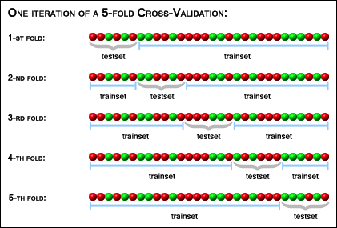

(source http://genome.tugraz.at/proclassify/help/pages/XV.html)

The data is randomly splitted in k sub-samples (usually 5 or 10). Sequentially, each sub-sample is held out, the models are developped using the others sub-samples and compared on the held out sub-samples. For each “fold”, the predictive performance criterion is saved, and the models are compared on their mean predictive performance criterion across the folds.

This limits the influence of specific held out dataset. To improve robustness to sampling, this procedure may be repeated several times (ex: repeat 10 times a 5-folds CV will allows to define different sub-samples), and the performances are averaged across all folds of all the repetition. This is however more computationally intensive.

If your dataset is still structured (ex: in the case of multicenter study), using the different unit (ex: center) to define sub-sample (instead random sampling) may produce more reliable results because each test dataset is an external dataset, limiting the selection of an overfitted model.

Let’s program a 5 fold CV with the **lung** dataset:

```r
table(idx) #check that we have approximatively the same number of each indicator
```

```
idx
 1  2  3  4  5
46 46 46 45 45
```

The results are highly dependent on the specific draw that was used (especially for small sample size), leading to unstable development: Different draws risk to produce different results (non-reproducible results), especially if you are unlucky and that the held out part include a lot of extreme values.